# RTSA SS23: Exercise Sheet 2

Martin Memmesheimer

Pranaya Tomar

03.05.2023

**FEEDBACK**

Leave this as it is, we fill it out while grading.

# Exercise 2.2

```r
data <- read.table("road-map-20.csv", sep = ",", header = TRUE)
road <- data$road
map <- data$map
```

## Part (a)

```r
calculate_parameters <- function(x, y) {
  N <- length(y)
  xN <- sum(x) / N
  yN <- sum(y) / N
  b2hat <- sum((y - yN) * (x - xN)) / sum((x - xN)^2)
  b1hat <- yN - b2hat * xN
  sigmahat <- sum((y - b1hat - b2hat * x)^2)
  return(c(b1hat, b2hat, sigmahat))
}
```

## Part (b)

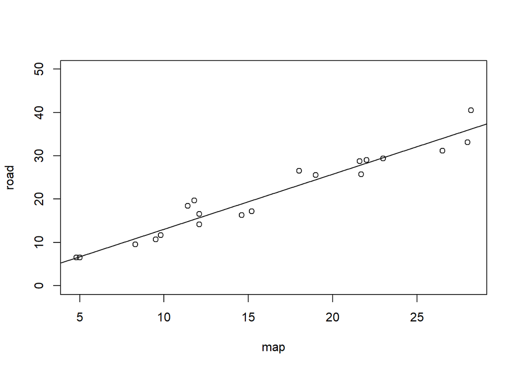

```r
parameters <- calculate_parameters(map, road)
plot(map, road, ylim = c(0, 50))
abline(parameters[1], parameters[2])
```

# Exercise 2.4

## Part (a)

```r
data_generation <- function(a, N, variance) {
  Z <- rnorm(N, sd = sqrt(variance))
  return(a + Z)
}

estimator1 <- function(data) {
  return(sum(data) / length(data))
}

estimator2 <- function(data) {
  return(median(data))
}

estimator3 <- function(data) {
  return(sum(data) / (length(data) + 1))
}

monte_carlo <- function(a, N, variance, m) {
  estimations_1 <- c()
  estimations_2 <- c()
  estimations_3 <- c()
  for(i in 1:m) {
    data_vector <- data_generation(a, N, variance)
    estimations_1 <- append(estimations_1, estimator1(data_vector))
    estimations_2 <- append(estimations_2, estimator2(data_vector))
    estimations_3 <- append(estimations_3, estimator3(data_vector))
  }
  estimations.data <- data.frame(
    estimations_1 = estimations_1,
    estimations_2 = estimations_2,
    estimations_3 = estimations_3
  )
 return(estimations.data)
}
```

## Part(b)

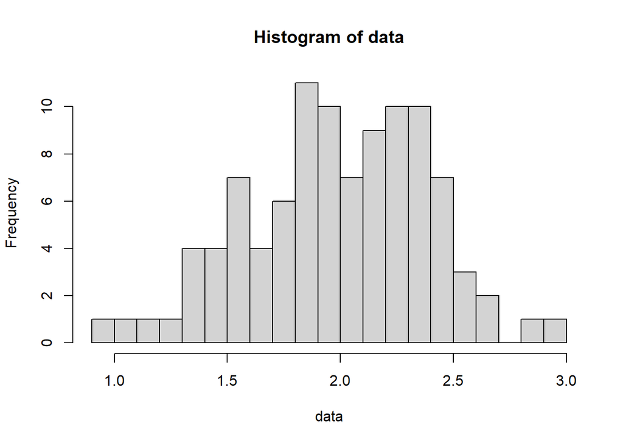

```r
data <- monte_carlo(2, 25, 4, 100)$estimations_1
hist(data, breaks = 15)
```

It looks like it is normally distributed with mean $2$. This makes sense since we know that $T_1$ is an unbiased estimator and the random variables $Y_i$ with which we generate the data are normally distributed as well.

## Part(c)

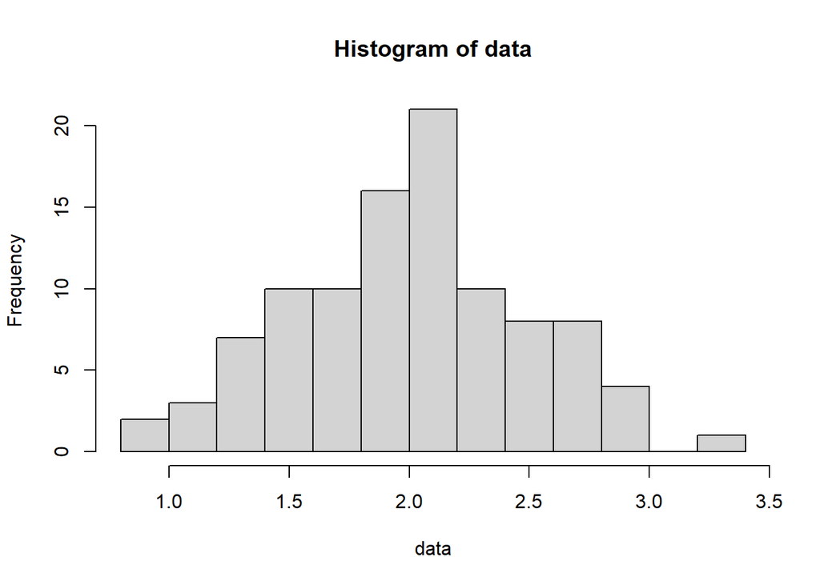

```r
data <- monte_carlo(2, 25, 4, 100)$estimations_2
hist(data, breaks = 15)
```

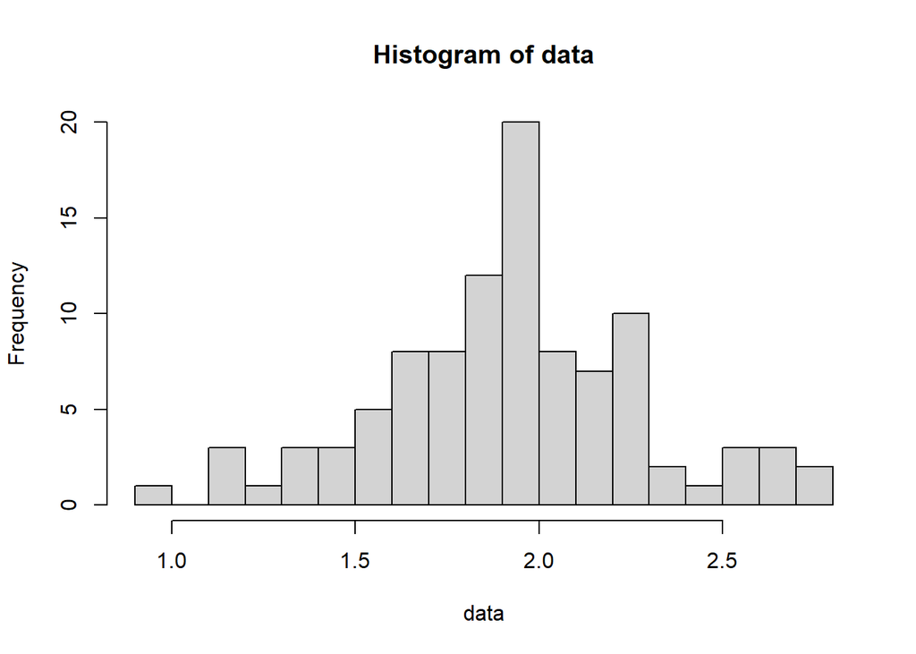

```r
data <- monte_carlo(2, 25, 4, 100)$estimations_3
hist(data, breaks = 15)
```

For $T_2$ it seems like there is a little bit more variance around $a$ than for the $T_1$. For $T_3$ it seems like there is a very small shift in where the estimations for a are centered. We know that $T_1$ and $T_2$ are unbiased estimators while $T_3$ is biased. This would explain the observation regarding the histogram for $T_3$